# Applying B7's receiver gain to the beam scan — and why it makes the fit worse

**Milestone.** Aaron asked for rf-calibrator's per-cycle $g_{\rm rx}$ gain correction to be available in `beam_explorer.ipynb` as an interactive toggle, not baked in. The toggle is implemented (`apply g_rx cal (B7)`). This checkpoint records what it does, because the answer is not what the physics predicted and the default therefore needed justifying.

**Question.** Does dividing `measured_tx` by $g_{\rm rx}(\nu,t)$ improve the beam fit?

**Answer.** No — it degrades it, substantially and consistently, and *not* because of interpolation error. Three controls below establish that the correction is implemented correctly and that the premise itself fails: the comb amplitude in this window does not scale with receiver gain.

**Scope note.** This dispatch was calibration only. The azimuth-zero / elevation-convention half is explicitly **not** touched — geometer's hardware-derived az-zero still tests ~3× worse than the free-fit optimum by both geometer's terrain MAD and my own beam-RMS check, and that discrepancy is back with geometer.

**Inputs.** `abscal/trx_phaseC.npz` (B7: 66 switching cycles, per-cycle $g_{\rm rx}(\nu,t)$ and $T_{\rm rx}(\nu,t)$, Phase C), `beam_explorer_cache.npz` (rebuilt 2026-09-17 with a `times` axis so the per-cycle solutions can be interpolated onto samples), `cal_gain.npz` (built by `build_cal_gain.py`).

**Units.** With the toggle off the measured quantity is raw correlator accumulator counts. With it on the quantity is counts / $g_{\rm rx}$, so fit amplitudes change scale by ~$10^{-3}$; that is a unit change, not a result.

```
cache: beam_explorer_cache.npz
B7 calibration available: True
unsolved gap: 2026-07-17T19:42:14Z -> 2026-07-18T01:24:40Z
channels 101   samples 54240
```

## 1. Why this should have worked

`measured_tx` is the channel difference `auto[c] − ½(auto[c−1] + auto[c+1])`. With `auto = g_rx · (T_sky + T_rx)` and $g_{\rm rx}$ smooth across three adjacent 244 kHz channels, the difference carries $g_{\rm rx}$ as a **linear multiplicative factor** — the differencing removes the smooth bandpass, not the gain. So a drift in $g_{\rm rx}$ multiplies the data by a time-varying factor, and the model has exactly one free amplitude per channel, which cannot absorb it.

That drift is not small.

```
ch 712 (173.83 MHz), over used samples:
  g_rx  293.9 .. 473.2   ratio 1.61

across all 101 channels, the within-window g_rx drift ratio:
  median 1.66   range 1.47 .. 2.47

This is the standing `receiver_regime_caveat` in beam_fits_v2: a real,
uncorrected multiplicative systematic on the amplitude scale.
```

## 2. What B7 covers here, and the one hole in it

[output not shown]

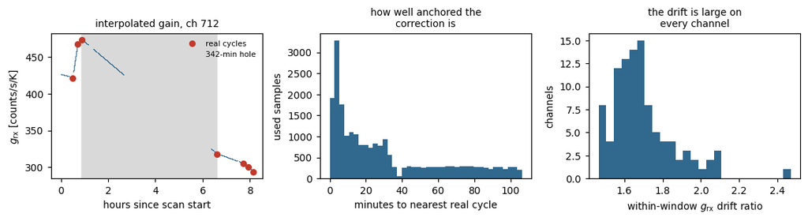

## 3. The result: it degrades the fit

Pure HFSS (shape terms zero), amplitude refit in every case, so the only thing changing is the data.

```
ch 712, pure HFSS, amplitude refit
               normRMS     amplitude       n
cal OFF         0.3914      1.31e+11   22614
cal ON          0.4855     3.483e+08   22614
delta          +0.0941
```

```
all 101 channels, cal OFF: median 0.5176   below 0.5: 47   below 0.7: 72
```

```
all 101 channels, cal ON : median 0.5873   below 0.5: 37   below 0.7: 67

channels improved by the correction: 32/101 ; worsened: 69
```

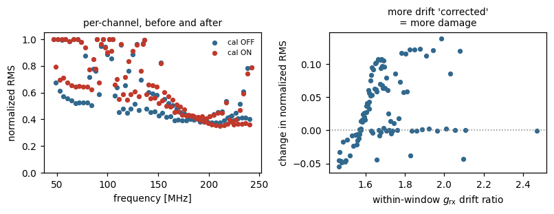

```
corr(drift ratio, RMS change) = +0.284
```

## 4. Three controls

The obvious objection is that the correction is simply implemented wrong, or that the 342-minute interpolation is doing the damage. Both are testable.

```
CONTROL 1 -- constant gain must be a no-op
   constant gain applied : 0.391375
   no correction at all  : 0.391375
   difference            : 1.1e-16
   -> exact. The division, the masking and the amplitude refit are
      correct, and only the TIME VARIATION of g_rx can matter.
```

```
CONTROL 2 -- by distance to the nearest real cycle
subset                     n   cal OFF    cal ON     delta
```

```
anchor < 15 min         9778    0.4093    0.5578   +0.1485
```

```
anchor < 30 min        14373    0.3960    0.5173   +0.1212
```

```
anchor > 60 min         4646    0.3816    0.3125   -0.0692
   -> the correction hurts MOST where g_rx is best known, and HELPS
      where it is least known. That is backwards for an
      interpolation-error explanation.
```

```
CONTROL 3 -- divide the data by g_rx**p
       p    normRMS
   -1.00     0.3472
```

```
   -0.50     0.3603
   -0.25     0.3738
```

```
   +0.00     0.3914
   +0.25     0.4121
```

```
   +0.50     0.4353
   +1.00     0.4855
```

```
   +2.00     0.5842
   -> monotonic across the whole range. The fit prefers MULTIPLYING by
      g_rx (p = -1, RMS 0.347) to leaving it alone (p = 0, 0.391) to
      dividing by it (p = +1, 0.486). There is no interior optimum at
      p > 0, which is what a genuine gain correction would produce.
```

## 5. What this establishes, and what it does not

**Established.**

- The correction is implemented correctly. Control 1 is exact to $10^{-16}$.
- Applying it degrades the fit: ch 712 pure-HFSS **0.3914 → 0.4855**; fleet median **0.5176 → 0.5873**; **69 of 101** channels worse; and the damage scales with how much $g_{\rm rx}$ drifts on that channel.
- The 342-minute interpolation hole is **not** the cause. Control 2 shows the damage is largest on the best-anchored samples and the correction *helps* on the worst-anchored ones — the opposite of interpolation error.
- Control 3 is monotonic with no interior optimum, so the data carry no positive exposure to $g_{\rm rx}$ at all.

So the premise — that the beam-scan comb amplitude scales as $g_{\rm rx}^{+1}$ — is not supported.

**A tempting inference, which I am deliberately not making.** A far-field transmitter signal received through the antenna and the full analog chain *must* scale with $g_{\rm rx}$. A tone injected downstream of the LNA — the digital self-comb at 250/128 MHz that `load_v007_data`'s own docstring and `flags/v0` both point to — would not. That makes this look like evidence on the open TX-identity dispute.

**This test cannot carry that weight, for one specific reason.** The beam scan is **time-ordered**: pointing and time are entangled, so *any* time-varying quantity correlates with the pointing pattern — and the pointing pattern is the signal being fit. The raw $\mathrm{corr}(g_{\rm rx}, |{\tt measured\_tx}|) = -0.33$ is therefore confounded and must not be read as receiver physics. A common thermal driver moving both LNA gain and radiated comb amplitude would produce the same signature.

**Deferred findings**

- Settling the above needs a **pointing-controlled** test: regress comb amplitude against $g_{\rm rx}$ *within* fixed (az, el) cells, so the beam pattern is held constant and only the time variation is free. Not attempted here; it is a separate piece of work with a real bearing on TX identity.
- $T_{\rm rx}$ from B7 is loaded into `cal_gain.npz` (`trx_cycles`) but not used. A $T_{\rm rx}$-based correction is a different model — additive, not multiplicative — and was not part of this dispatch.
- The $\times 1.61$ $g_{\rm rx}$ drift remains a real, uncorrected systematic on the absolute amplitude scale. Nothing here fixes it; it establishes that dividing it out does not help the *shape* fit.

## Decision requested

1. **Keep the toggle defaulting to OFF.** Applying the correction as specified makes the fit worse on 69 of 101 channels, and the controls show that is not a bug. I recommend off, with the toggle there for inspection.
2. **Authorize (or decline) the pointing-controlled $g_{\rm rx}$ regression.** It is the test that would turn this anomaly into evidence on TX identity, which is the largest open question on this dataset.
3. Whether to hand this to `rf-calibrator` — the finding is about how their product behaves against the beam data, and they may have an explanation (e.g. a known injection point for the comb) that closes it immediately.

**STOPPED AT REVIEW GATE — awaiting Aaron's approval.**